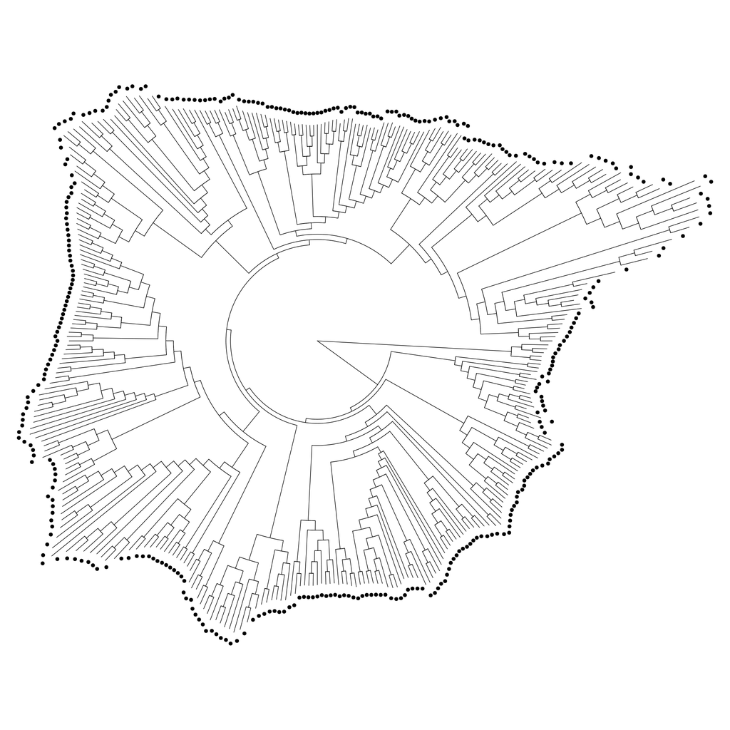

# Doctoral Thesis Document

Document “Thesis_IRamosGutierrez.pdf” is the complete dissertation document.

# PhD code

Code used for the PhD

Although the folder structure is explicited, the files are not uploaded due to storage limitations, and, in some cases, confidentiality. However, most of them are public or downloadable in open repositories. Nevertheless, please feel free to contact and ask for any particular file ypu might be interested in!

Folder “1. AFLIBER” includes code to perform the gbif lookup and filter given the uploaded files (includes species list, provinces to filter and 10x10 UTM grid). This lookup was performed prior to july 2020, and some used packages may be now outdated.

The information regarding chapter 2 (randtip) has not been uploaded here as it can be checked at its own GitHub repository (https://github.com/iramosgutierrez/randtip).

Folder “3. Iberian Bioregions” includes the code used to carry out the analyses described in that chapter. The analyses between bioregions and variables are included in an external script, and loaded in the main one (as the results may differe among rus due to stochasticity).

Folder “4. Iberian EDGE” includes code to develop all the methods described in that chapter. Some of the scripts (`Iberian_EDGE_cluster.R`) have been designed to work in a HPC, so running them in a personal computer might not be optimous.